# Access to Acacia

In this tutorial we are going to set up your access keys. Acacia is built with a low cost storage techonology called [Ceph](https://ceph.io/en/discover/). The Amazon S3 protocol can be used to transfer information to and from Acacia using HTTPS connections. Each connection to Acacia requires two pieces of information that makes up a key pair.

- Access ID
- Secret Key

The **Access ID** and **Secret Key** key pair are just strings of text, similar to a username and password. They are associated with your personal storage or project allocation. You can have up to **5** of your own key pairs active for any storage allocation at any one time. There is no need to share key pairs among project members because each of you can have your own set of keys. In this tutorial the goal is to fetch some key pairs and save it to your computer.

## Pawsey account

A Pawsey account with a working password is **essential**. These have been provided for the workshop, but if you are working with Pawsey using your normal credentials and you don't know your password you can reset it here.

https://support.pawsey.org.au/password-reset/

## Obtaining an access key

You can get this information by logging onto the Pawsey user portal at https://portal.pawsey.org.au then clicking on the "ACACIA -> MANAGE ACACIA KEYS" link in the menu bar.

[figure not shown]

Figure: Link to manage access keys.

### Creating key pairs

Here you have the ability to create a key pair to access your personal storage (100GB) or to access your project/s storage (>=1 TB). At this stage select your username from "Storage Name" in order to use personal storage. You may also create an access key for use by your project by selecting your project name from "Storage Name". By default an **Access ID** is created for your personal storage, but it isn't useful because the **Secret Key** is missing. Delete the old Access ID and click "Create New Key" to create a new key pair.

[figure not shown]

Figure: Setup key pairs.

In the window that appears there will be an Access ID and Secret Key, plus some instructions for Rclone, and AWS CLI clients.

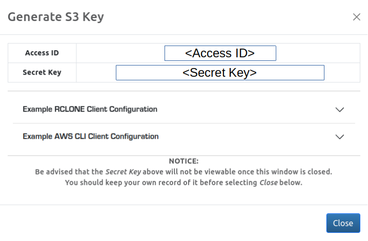

Figure: Key pair information.

This is the **only** time the Secret Key will be visible. Copy your Access ID and Secret Key to a secure location on your computer or home directory, and set permissions so only you can see the file.

When you need access to your project storage then repeat these instructions for the project key.

> Note: All keys (including those to access project storage) belong to a user. Keys to access project storage should **not** be shared amongst project users. Every user in the project allocation can create their own keys to access project storage.

## Best practices with Acacia keys

It's really important to note that only you can access your key pair. Anyone who has the key pair has the same access to files on Acacia as you do.

- Never embed your Access ID or Secret Key in programs or scripts
- Always store your keys in a file that is readable only by you
  - On a Unix system you can do `chmod 600 file` to make your keys file readable by you only.
- Use environment variables to store your Access ID and Secret Key
- Change your access keys periodically
- Delete keys you no longer need
- Don't share your keys with anyone else.